# Hybrid Models Tutorial

# Necessary Libraries

```r
library(tidyverse)
library(forecast)
library(tseries)
library(prophet)
library(lubridate)
library(bsts)
```

# Introduction

In this tutorial, hybrid models are used to model a univariate time series. In this case, data for Climate Change CH4 starting from 1983 May to 2009 monthly data is used.

# Getting Data

```r
data=read.csv("climate_change.csv")
data=data$CH4
head(data)
```

```
## [1] 1638.59 1633.71 1633.22 1631.35 1648.40 1663.79
```

```r
tsdata=ts(data,start=c(1983,5),frequency = 12)
```

# Splitting Data into Two Parts

```r
train=window(tsdata,end=c(2007,12))
test=window(tsdata,start=2008)

train_date_start="1983/05/01"
train_date_end="2007/12/01"

test_date_start="2008/01/01"
test_date_end="2008/12/01"
```

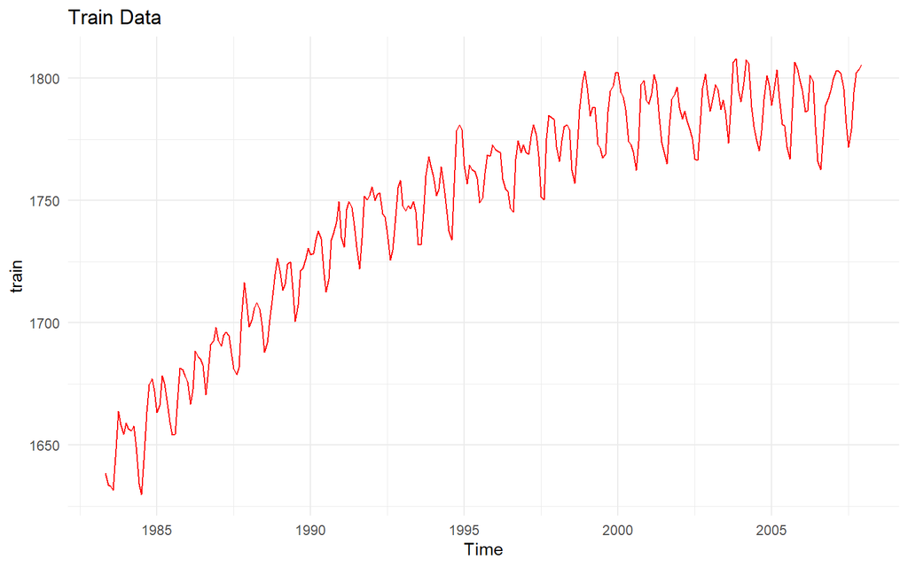

```r
autoplot(train,main="Train Data",col="red")+theme_minimal()
```

# Time Series Decomposition

First of all, time series is divided into 3 parts, namely seasonal, trend and remainder component by STL.

```r
decomposed=stl(train ,s.window = "periodic")
seasonal=decomposed$time.series[,1]
trend=decomposed$time.series[,2]
remainder=decomposed$time.series[,3]
```

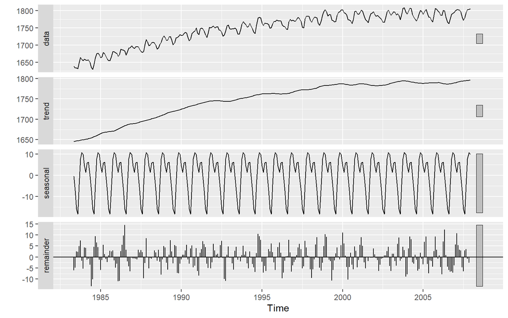

```r
autoplot(decomposed)
```

# Modeling

```r
set.seed(1234)
#For Seasonal Component
seasonal_arima=auto.arima(seasonal)
seasonal_ets=ets(seasonal)
seasonal_tbats=tbats(seasonal)
seasonal_nnar=nnetar(seasonal)
seasonal_arfima=arfima(seasonal)
seasonal_stlm=stlm(seasonal)
seasonal_holt=holt(seasonal,h=length(test))


#For Trend Component
trend_arima=auto.arima(trend)
trend_ets=ets(trend)
trend_tbats=tbats(trend)
trend_nnar=nnetar(trend)
trend_arfima=arfima(trend)
trend_stlm=stlm(trend)
trend_holt=holt(trend,h=length(test))

#For Remainder Component
remainder_arima=auto.arima(remainder)
remainder_ets=ets(remainder)
remainder_tbats=tbats(remainder)
remainder_nnar=nnetar(remainder)
remainder_arfima=arfima(remainder)
remainder_stlm=stlm(remainder)
remainder_holt=holt(remainder,h=length(test))
```

```r
#for prophet
ds=c(seq(as.Date(train_date_start),as.Date(train_date_end),by="month"))
test_ds<-c(seq(as.Date(test_date_start),as.Date(test_date_end),by="month"))
#for seasonal component
df_prophet_seasonal=data.frame(ds,y=as.numeric(seasonal))
model_prophet_seasonal <- prophet(df_prophet_seasonal)
future_seasonal<-make_future_dataframe(model_prophet_seasonal,periods = length(test),freq = "month")
forecast_seasonal <- predict(model_prophet_seasonal, future_seasonal)
prophet_fitted_seasonal= forecast_seasonal$yhat[1:length(train)]
prophet_forecast_seasonal=tail(forecast_seasonal$yhat,length(test))

#for trend component
df_prophet_trend=data.frame(ds,y=as.numeric(trend))
model_prophet_trend <- prophet(df_prophet_trend)
future_trend<-make_future_dataframe(model_prophet_trend,periods = length(test),freq = "month")
forecast_trend <- predict(model_prophet_trend, future_trend)
prophet_fitted_trend= forecast_trend$yhat[1:length(train)]
prophet_forecast_trend=tail(forecast_trend$yhat,length(test))

#for remainder component
df_prophet_remainder=data.frame(ds,y=as.numeric(remainder))
model_prophet_remainder <- prophet(df_prophet_remainder)
future_remainder<-make_future_dataframe(model_prophet_remainder,periods = length(test),freq = "month")
forecast_remainder <- predict(model_prophet_remainder, future_remainder)
prophet_fitted_remainder= forecast_remainder$yhat[1:length(train)]
prophet_forecast_remainder=tail(forecast_remainder$yhat,length(test))
```

```r
#seasonal
ss <- AddLocalLinearTrend(list(), seasonal)
ss <- AddSeasonal(ss, seasonal, nseasons = 12)
bsts.model <- bsts(seasonal, state.specification = ss, niter = 500, ping=0, seed=2016)

burn <- SuggestBurn(0.1, bsts.model)

bayes_seasonal_f <- as.numeric(predict.bsts(bsts.model, horizon = length(test), burn = burn, quantiles = c(.025, .975))$mean)

bayes_seasonal_fitted=as.numeric(-colMeans(bsts.model$one.step.prediction.errors[-(1:burn),])+seasonal)


#trend
ss <- AddLocalLinearTrend(list(), trend)
ss <- AddSeasonal(ss, trend, nseasons = 12)
bsts.model <- bsts(trend, state.specification = ss, niter = 500, ping=0, seed=2016)

burn <- SuggestBurn(0.1, bsts.model)

bayes_trend_f <- as.numeric(predict.bsts(bsts.model, horizon = length(test), burn = burn, quantiles = c(.025, .975))$mean)

bayes_trend_fitted=as.numeric(-colMeans(bsts.model$one.step.prediction.errors[-(1:burn),])+trend)


#remainder
ss <- AddLocalLinearTrend(list(), remainder)
ss <- AddSeasonal(ss, remainder, nseasons = 12)
bsts.model <- bsts(remainder, state.specification = ss, niter = 500, ping=0, seed=2016)

burn <- SuggestBurn(0.1, bsts.model)

bayes_remainder_f <- as.numeric(predict.bsts(bsts.model, horizon = length(test), burn = burn, quantiles = c(.025, .975))$mean)

bayes_remainder_fitted=as.numeric(-colMeans(bsts.model$one.step.prediction.errors[-(1:burn),])+remainder)
```

```r
#Forecasting (Other models)

#For Seasonal Component
seasonal_arima_f=forecast(seasonal_arima,h=length(test))$mean
seasonal_ets_f=forecast(seasonal_ets,h=length(test))$mean
seasonal_tbats_f=forecast(seasonal_tbats,h=length(test))$mean
seasonal_nnar_f=forecast(seasonal_nnar,h=length(test))$mean
seasonal_arfima_f=forecast(seasonal_arfima,h=length(test))$mean
seasonal_stlm_f=forecast(seasonal_stlm,h=length(test))$mean
seasonal_holt_f=seasonal_holt$mean

#For Trend Component
trend_arima_f=forecast(trend_arima,h=length(test))$mean
trend_ets_f=forecast(trend_ets,h=length(test))$mean
trend_tbats_f=forecast(trend_tbats,h=length(test))$mean
trend_nnar_f=forecast(trend_nnar,h=length(test))$mean
trend_arfima_f=forecast(trend_arfima,h=length(test))$mean
trend_stlm_f=forecast(trend_stlm,h=length(test))$mean
trend_holt_f=trend_holt$mean


#For Remainder Component
remainder_arima_f=forecast(remainder_arima,h=length(test))$mean
remainder_ets_f=forecast(remainder_ets,h=length(test))$mean
remainder_tbats_f=forecast(remainder_tbats,h=length(test))$mean
remainder_nnar_f=forecast(remainder_nnar,h=length(test))$mean
remainder_arfima_f=forecast(remainder_arfima,h=length(test))$mean
remainder_stlm_f=forecast(remainder_stlm,h=length(test))$mean
remainder_holt_f=remainder_holt$mean
```

After getting fitted and forecasted values for each model, let’s combine them into one dataframe for each component seperately.

```r
seasonal_df=data.frame(seasonal_arima_f,seasonal_ets_f,
                       seasonal_tbats_f,seasonal_nnar_f,prophet_forecast_seasonal,
                       bayes_seasonal_f,seasonal_arfima_f,seasonal_stlm_f,seasonal_holt_f)

trend_df=data.frame(trend_arima_f,trend_ets_f,trend_tbats_f,trend_nnar_f,prophet_forecast_trend,
                    bayes_trend_f,trend_arfima_f,trend_stlm_f,trend_holt_f)

remainder_df=data.frame(remainder_arima_f,
                        remainder_ets_f,remainder_tbats_f,remainder_nnar_f,
                        prophet_forecast_remainder,bayes_remainder_f,remainder_arfima_f,
                        remainder_stlm_f,remainder_holt_f)
```

```r
head(seasonal_df) #forecasts for seasonal component
```

```
##   seasonal_arima_f seasonal_ets_f seasonal_tbats_f seasonal_nnar_f
## 1        4.3178183      4.3178183        4.3177703       4.3194178
## 2        1.4945586      1.4945586        1.4946378       1.4948705
## 3        5.7113020      5.7113020        5.7111780       5.7095738
## 4        6.2290672      6.2290672        6.2292115       6.2283734
## 5       -0.5177717     -0.5177717       -0.5178938      -0.5183676
## 6       -7.2291662     -7.2291662       -7.2290491      -7.2298608
##   prophet_forecast_seasonal bayes_seasonal_f seasonal_arfima_f seasonal_stlm_f
## 1                 4.3085381        4.3181759          0.394536       4.3178183
## 2                 1.5213141        1.5035888         -9.108285       1.4945586
## 3                 5.6549822        5.7180297         -7.320750       5.7113020
## 4                 6.1682923        6.2346472         -1.617819       6.2290672
## 5                -0.5654105       -0.5178606          3.578215      -0.5177717
## 6                -7.2536458       -7.2256454          7.836810      -7.2291662
##   seasonal_holt_f
## 1        9.879244
## 2        9.916654
## 3        9.954064
## 4        9.991475
## 5       10.028885
## 6       10.066295
```

```r
#1: ARIMA, 2: ETS, 3:TBATS  , 4: NNETAR , 5: Prophet , 6: Bayesian , 7: ARFIMA , 8: STLM , 9: HOLT
model_accuracy_hybrid=function(seasonal,trend,remainder,test){
  forecasts=seasonal_df[,seasonal]+trend_df[,trend]+remainder_df[,remainder]
  accuracy(forecasts,test)
}
```

In this model_accuracy_hybrid() function, I considered using their corresponding values for different values. For example, when seasonal=1, it represents the ARIMA model since it is the first column of that dataframe and so on.

```r
#For example, Fitting Seasonal part as ARIMA, trend as ARIMA and Remainder as ARIMA
model_accuracy_hybrid(seasonal=1,trend=1,remainder=1,test)
```

```
##                 ME     RMSE      MAE        MPE     MAPE      ACF1 Theil's U
## Test set 0.4542875 5.583228 4.180005 0.02412093 0.232002 0.3562085 0.5972256
```

```r
#Fitting an auto.arima model directly
accuracy(forecast(auto.arima(train),h=12)$mean,test)
```

```
##                 ME     RMSE      MAE        MPE      MAPE     ACF1 Theil's U
## Test set 0.3496631 5.698932 4.235391 0.01850687 0.2352549 0.413143 0.6308463
```

Here, I considered using ARIMA model for each component separately and auto.arima function directly. As it is seen from the accuracy measures, mostly the hybrid models works better even we use ARIMA model for each component separately.

```r
forecasts=as.data.frame(matrix(ncol=7,nrow=9^3))
colnames(forecasts)=c("ME","RMSE","MAE","MPE","MAPE","ACF1","Theil's U")


a=1
for(i in 1:9){
  for(j in 1:9){
    for(k in 1:9){
      forecasts[a,]=model_accuracy_hybrid(seasonal=i,trend=j,remainder=k,test=test)[1,]
      rownames(forecasts)[a]=paste("Seasonal:",as.character(i),"Trend:",as.character(j),"Remainder:",as.character(k))
      a=a+1

    }
  }
}
```

Here, rownames represent seasonal,trend,remainder accordingly,

where **1: ARIMA, 2: ETS, 3:TBATS , 4: NNETAR , 5: PROPHET , 6: Bayesian , 7: ARFIMA , 8: STLM , 9: HOLT**

```r
head(forecasts,10)
```

```
##                                          ME     RMSE      MAE        MPE
## Seasonal: 1 Trend: 1 Remainder: 1 0.4542875 5.583228 4.180005 0.02412093
## Seasonal: 1 Trend: 1 Remainder: 2 0.5064339 5.805445 4.288465 0.02697917
## Seasonal: 1 Trend: 1 Remainder: 3 0.4712763 5.531792 4.138177 0.02505125
## Seasonal: 1 Trend: 1 Remainder: 4 0.3281435 7.929866 6.620652 0.01799452
## Seasonal: 1 Trend: 1 Remainder: 5 0.4989024 5.840901 4.312722 0.02654102
## Seasonal: 1 Trend: 1 Remainder: 6 0.3779219 5.879614 4.276179 0.01981733
## Seasonal: 1 Trend: 1 Remainder: 7 0.4170285 5.579565 4.143380 0.02206525
## Seasonal: 1 Trend: 1 Remainder: 8 0.5182584 6.376155 4.650285 0.02772336
## Seasonal: 1 Trend: 1 Remainder: 9 0.4022379 5.797294 4.258169 0.02118607
## Seasonal: 1 Trend: 2 Remainder: 1 0.9913357 5.686207 4.403512 0.05401583
##                                        MAPE      ACF1 Theil's U
## Seasonal: 1 Trend: 1 Remainder: 1 0.2320020 0.3562085 0.5972256
## Seasonal: 1 Trend: 1 Remainder: 2 0.2379847 0.3641986 0.5995155
## Seasonal: 1 Trend: 1 Remainder: 3 0.2296560 0.3520717 0.5896785
## Seasonal: 1 Trend: 1 Remainder: 4 0.3682021 0.3815144 0.8477543
## Seasonal: 1 Trend: 1 Remainder: 5 0.2393247 0.3640536 0.6029762
## Seasonal: 1 Trend: 1 Remainder: 6 0.2373270 0.3529168 0.6056343
## Seasonal: 1 Trend: 1 Remainder: 7 0.2299696 0.3573497 0.5980492
## Seasonal: 1 Trend: 1 Remainder: 8 0.2582143 0.3806246 0.6683829
## Seasonal: 1 Trend: 1 Remainder: 9 0.2363201 0.3642020 0.6002959
## Seasonal: 1 Trend: 2 Remainder: 1 0.2443602 0.3683094 0.6100710
```

Now, let’s obtain different models for different accuracy measures.

```r
forecasts[which.min(forecasts$ME), ] #min ME
```

```
##                                          ME     RMSE      MAE        MPE
## Seasonal: 9 Trend: 1 Remainder: 4 -9.756857 13.50937 11.45027 -0.5454151
##                                        MAPE      ACF1 Theil's U
## Seasonal: 9 Trend: 1 Remainder: 4 0.6388749 0.4869935  1.569592
```

```r
forecasts[which.min(forecasts$RMSE), ] #min RMSE
```

```
##                                          ME     RMSE      MAE        MPE
## Seasonal: 5 Trend: 6 Remainder: 3 0.5504279 5.461168 4.059905 0.02953179
##                                        MAPE      ACF1 Theil's U
## Seasonal: 5 Trend: 6 Remainder: 3 0.2253348 0.3370276 0.5814976
```

```r
forecasts[which.min(forecasts$MAE), ] #min MAE
```

```
##                                          ME     RMSE      MAE        MPE
## Seasonal: 5 Trend: 6 Remainder: 3 0.5504279 5.461168 4.059905 0.02953179
##                                        MAPE      ACF1 Theil's U
## Seasonal: 5 Trend: 6 Remainder: 3 0.2253348 0.3370276 0.5814976
```

```r
forecasts[which.min(forecasts$MPE), ] #min MPE
```

```
##                                          ME     RMSE      MAE        MPE
## Seasonal: 9 Trend: 1 Remainder: 4 -9.756857 13.50937 11.45027 -0.5454151
##                                        MAPE      ACF1 Theil's U
## Seasonal: 9 Trend: 1 Remainder: 4 0.6388749 0.4869935  1.569592
```

```r
forecasts[which.min(forecasts$MAPE), ] #min MAPE
```

```
##                                          ME     RMSE      MAE        MPE
## Seasonal: 5 Trend: 6 Remainder: 3 0.5504279 5.461168 4.059905 0.02953179
##                                        MAPE      ACF1 Theil's U
## Seasonal: 5 Trend: 6 Remainder: 3 0.2253348 0.3370276 0.5814976
```

```r
forecasts[which.min(forecasts$ACF1), ] #min ACF1
```

```
##                                          ME     RMSE      MAE        MPE
## Seasonal: 5 Trend: 6 Remainder: 3 0.5504279 5.461168 4.059905 0.02953179
##                                        MAPE      ACF1 Theil's U
## Seasonal: 5 Trend: 6 Remainder: 3 0.2253348 0.3370276 0.5814976
```

```r
forecasts[which.min(forecasts$`Theil's U`), ] #min Theil's U
```

```
##                                          ME     RMSE      MAE        MPE
## Seasonal: 5 Trend: 6 Remainder: 3 0.5504279 5.461168 4.059905 0.02953179
##                                        MAPE      ACF1 Theil's U
## Seasonal: 5 Trend: 6 Remainder: 3 0.2253348 0.3370276 0.5814976
```

It is seen that, using the model 5-6-3 seems useful.

```r
model_accuracy_hybrid(seasonal=5,trend=6,remainder=3,test)
```

```
##                 ME     RMSE      MAE        MPE      MAPE      ACF1 Theil's U
## Test set 0.5504279 5.461168 4.059905 0.02953179 0.2253348 0.3370276 0.5814976
```

Remark : **1: ARIMA, 2: ETS, 3:TBATS , 4: NNETAR , 5: PROPHET , 6: Bayesian , 7: ARFIMA , 8: STLM , 9: HOLT**

# Plotting the Best Model

```r
fitted=ts(prophet_fitted_seasonal,start=start(train),frequency = 12)+ bayes_trend_fitted + remainder_tbats$fitted.values
forecasted_val=prophet_forecast_seasonal+bayes_trend_f+remainder_tbats_f
```

```r
accuracy_train=accuracy(fitted,train)
accuracy_test=accuracy(forecasted_val,test)
accuracy_bestmodel=rbind(accuracy_train,accuracy_test)
rownames(accuracy_bestmodel)=c("Train Set","Test Set")
accuracy_bestmodel
```

```
##                  ME     RMSE      MAE        MPE      MAPE        ACF1
## Train Set 0.2013268 3.034342 2.440540 0.01162673 0.1397821 -0.03289242
## Test Set  0.5504279 5.461168 4.059905 0.02953179 0.2253348  0.33702763
##           Theil's U
## Train Set 0.3443452
## Test Set  0.5814976
```

```r
prophet_forecast_seasonal
```

```
##  [1]   4.3085381   1.5213141   5.6549822   6.1682923  -0.5654105  -7.2536458
##  [7] -15.8786665 -18.1562435  -4.2892383   7.9111033  10.7911549   9.8866574
```

Let’s plot the components separately.

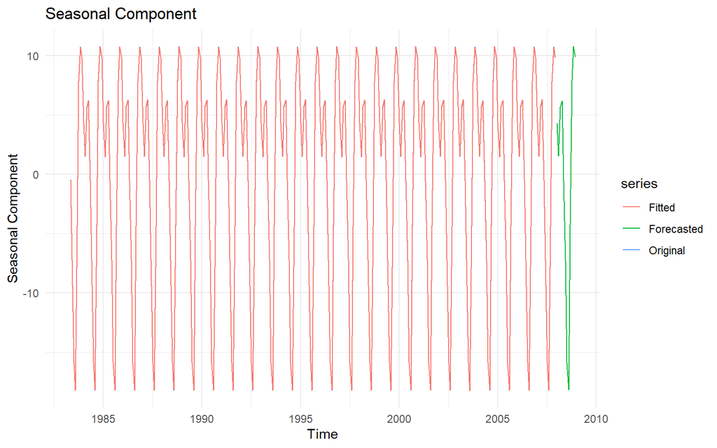

```r
autoplot(decomposed$time.series[,1],ylab="Seasonal Component",series="Original",main="Seasonal Component")+
  autolayer(ts(prophet_fitted_seasonal,start=start(train),frequency = 12),series="Fitted")+
  autolayer(ts(prophet_forecast_seasonal,start=2008,frequency = 12),series="Forecasted")+theme_minimal()
```

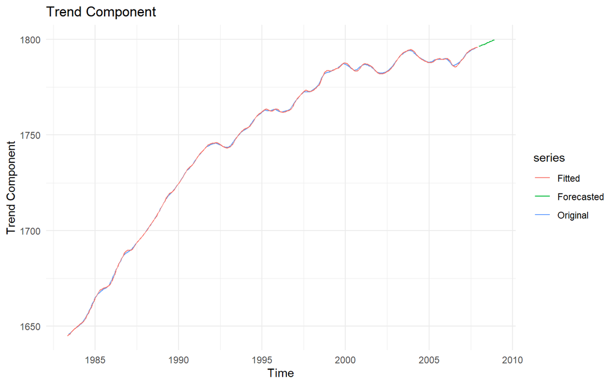

```r
autoplot(decomposed$time.series[,2],ylab="Trend Component",series="Original",main="Trend Component")+
  autolayer(ts(bayes_trend_fitted,start=start(train),frequency = 12),series="Fitted")+
  autolayer(ts(bayes_trend_f,start=2008,frequency = 12),series="Forecasted")+theme_minimal()
```

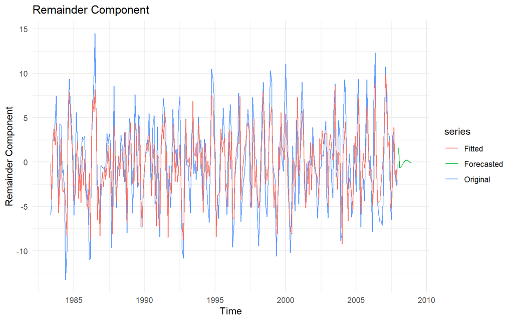

```r
autoplot(decomposed$time.series[,3],ylab="Remainder Component",series="Original",main="Remainder Component")+
  autolayer(remainder_tbats$fitted.values,series="Fitted")+
  autolayer(remainder_tbats_f,series="Forecasted")+theme_minimal()
```

Finally, let’s sum the components so that we would obtain the original series with test dataset.

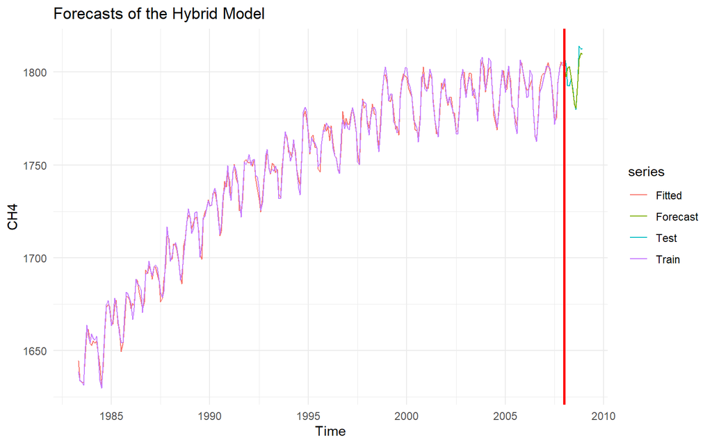

```r
autoplot(fitted,series="Fitted",main = "Forecasts of the Hybrid Model",ylab="CH4")+
  autolayer(train,series="Train")+
  autolayer(test,series="Test")+
  autolayer(forecasted_val,series="Forecast")+
  geom_vline(xintercept=2008,col="red",size=1)+theme_minimal()
```